# IE360 HW2

Emre Burak Baş - 2018402096

# 1. Introduction

The aim of this study is to build a time series regression model in order to find most probable factors affecting the unleaded gas sales and to be able to predict future values of unleaded gas sales.

# 2. Pre-Analysis Steps

## 2.1. Importing Necessary Packages

```r
library("tidyverse")
library("skimr")
library("tsibble")
library("forecast")
library("GGally")
```

## 2.2. Reading the Data and Taking the First Look

```r
data <- read_csv("IE360_Spring22_HW2_data.csv")
data %>% slice_head(n=5)
```

| Quarter | Unleaded Gasoline Sale (UGS) | RNUV | # LPG Vehicles (NLPG) | Price of Unleaded Gasoline (PU) | Price of Diesel Gasoline (PG) | # Unleaded Gasoline Vehicles (NUGV) | # of Diesel Gasoline Vehicles (NDGV) | GNP Agriculture | GNP Commerce | GNP Total |
| --- | --- | --- | --- | --- | --- | --- | --- | --- | --- | --- |
| 2000_Q1 | 1 128 971 | 0.0146 | 940 000 | 469.03 | 355.69 | 4 647 500 | 281.9853 | 1 040 173 | 3 483 132 | 18 022 686 |
| 2000_Q2 | 1 199 569 | 0.0205 | 941 000 | 459.42 | 344.58 | 4 742 876 | 284.0813 | 1 760 460 | 4 525 451 | 21 797 130 |
| 2000_Q3 | 1 370 167 | 0.0207 | 943 500 | 439.98 | 327.21 | 4 840 931 | 286.7169 | 6 974 808 | 5 915 204 | 30 050 207 |
| 2000_Q4 | 1 127 548 | 0.0163 | 948 000 | 402.08 | 300.67 | 4 919 685 | 288.3137 | 3 267 125 | 4 929 778 | 24 480 153 |
| 2001_Q1 | 1 033 918 | 0.0071 | 950 000 | 411.58 | 305.75 | 4 954 754 | 287.6237 | 1 004 528 | 3 418 387 | 15 832 648 |

> UGS: Unleaded gasoline sale in a given quarter,  
> RNUV: An index indicating the rate of new unleaded gasoline using vehicles being added to the traffic in a quarter,  
> PU: Average price (adjusted with an index) of a liter of unleaded gasoline in a quarter,  
> PG: Average price (adjusted with an index) of a liter of diesel gasoline in a quarter,  
> NUGV: Number of unleaded gasoline using vehicles in the traffic,  
> NDGV: Number of diesel gasoline using vehicles in the traffic (per 1000 people),  
> GNPA: Agriculture component of Gross National Product (adjusted with an index),  
> GNPC: Commerce component of Gross National Product (adjusted with an index),  
> GNP: Grand total for GNP (agriculture, commerce and other components total).

## 2.3. Initial Data Manipulations

To start with, I renamed the columns to turn them into short acronyms.

```r
data <- data %>%
  rename_with(~ tolower(gsub(" ", "_", .x, fixed = TRUE))) %>%
  rename(
    ugs = "unleaded_gasoline_sale_(ugs)",
    nlpg = "#_lpg_vehicles_(nlpg)",
    pu = "price_of_unleaded_gasoline_(pu)",
    pg = "price_of_diesel_gasoline_(pg)",
    nugv = "#_unleaded_gasoline_vehicles_(nugv)",
    ndgv = "#_of_diesel_gasoline_vehicles_(ndgv)"
  )

data %>% slice_head(n=5)
```

| quarter | ugs | rnuv | nlpg | pu | pg | nugv | ndgv | gnp_agriculture | gnp_commerce | gnp_total |
| --- | --- | --- | --- | --- | --- | --- | --- | --- | --- | --- |
| 2000_Q1 | 1 128 971 | 0.0146 | 940 000 | 469.03 | 355.69 | 4 647 500 | 281.9853 | 1 040 173 | 3 483 132 | 18 022 686 |
| 2000_Q2 | 1 199 569 | 0.0205 | 941 000 | 459.42 | 344.58 | 4 742 876 | 284.0813 | 1 760 460 | 4 525 451 | 21 797 130 |
| 2000_Q3 | 1 370 167 | 0.0207 | 943 500 | 439.98 | 327.21 | 4 840 931 | 286.7169 | 6 974 808 | 5 915 204 | 30 050 207 |
| 2000_Q4 | 1 127 548 | 0.0163 | 948 000 | 402.08 | 300.67 | 4 919 685 | 288.3137 | 3 267 125 | 4 929 778 | 24 480 153 |
| 2001_Q1 | 1 033 918 | 0.0071 | 950 000 | 411.58 | 305.75 | 4 954 754 | 287.6237 | 1 004 528 | 3 418 387 | 15 832 648 |

Also, some columns such as “nlpg” and “nugv” is stored in string format since they have whitespace inside these. So, I got rid of those and turned these columns into integers.

```r
data <- data %>%
  mutate(
    ugs = as.integer(str_remove_all(ugs, " ")),
    nlpg = as.integer(str_remove_all(nlpg, " ")),
    nugv = as.integer(str_remove_all(nugv, " ")),
    gnp_agriculture = as.integer(str_remove_all(gnp_agriculture, " ")),
    gnp_commerce = as.integer(str_remove_all(gnp_commerce, " ")),
    gnp_total = as.integer(str_remove_all(gnp_total, " ")),
  )

data %>% slice_head(n=5)
```

| quarter | ugs | rnuv | nlpg | pu | pg | nugv | ndgv | gnp_agriculture | gnp_commerce | gnp_total |
| --- | --- | --- | --- | --- | --- | --- | --- | --- | --- | --- |
| 2000_Q1 | 1128971 | 0.0146 | 940000 | 469.03 | 355.69 | 4647500 | 281.9853 | 1040173 | 3483132 | 18022686 |
| 2000_Q2 | 1199569 | 0.0205 | 941000 | 459.42 | 344.58 | 4742876 | 284.0813 | 1760460 | 4525451 | 21797130 |
| 2000_Q3 | 1370167 | 0.0207 | 943500 | 439.98 | 327.21 | 4840931 | 286.7169 | 6974808 | 5915204 | 30050207 |
| 2000_Q4 | 1127548 | 0.0163 | 948000 | 402.08 | 300.67 | 4919685 | 288.3137 | 3267125 | 4929778 | 24480153 |
| 2001_Q1 | 1033918 | 0.0071 | 950000 | 411.58 | 305.75 | 4954754 | 287.6237 | 1004528 | 3418387 | 15832648 |

“quarter” column is also currently stored in string format, so I turned it into “yearquarter” data format, provided by “tsibble” package, used for tidyverse-compatible time series objects.

```r
data <- data %>%
  mutate(
    yearquarter = yearquarter(quarter)
  )

data %>% slice_head(n=5)
```

| quarter | ugs | rnuv | nlpg | pu | pg | nugv | ndgv | gnp_agriculture | gnp_commerce | gnp_total | yearquarter |
| --- | --- | --- | --- | --- | --- | --- | --- | --- | --- | --- | --- |
| 2000_Q1 | 1128971 | 0.0146 | 940000 | 469.03 | 355.69 | 4647500 | 281.9853 | 1040173 | 3483132 | 18022686 | 2000 Q1 |
| 2000_Q2 | 1199569 | 0.0205 | 941000 | 459.42 | 344.58 | 4742876 | 284.0813 | 1760460 | 4525451 | 21797130 | 2000 Q2 |
| 2000_Q3 | 1370167 | 0.0207 | 943500 | 439.98 | 327.21 | 4840931 | 286.7169 | 6974808 | 5915204 | 30050207 | 2000 Q3 |
| 2000_Q4 | 1127548 | 0.0163 | 948000 | 402.08 | 300.67 | 4919685 | 288.3137 | 3267125 | 4929778 | 24480153 | 2000 Q4 |
| 2001_Q1 | 1033918 | 0.0071 | 950000 | 411.58 | 305.75 | 4954754 | 287.6237 | 1004528 | 3418387 | 15832648 | 2001 Q1 |

## 2.4. Summarizing the Data

```r
skim(data)
```

```
── Data Summary ────────────────────────
                           Values
Name                       data
Number of rows             32
Number of columns          12
_______________________
Column type frequency:
  character                2
  numeric                  10
________________________
Group variables            None

── Variable type: character ─────────────────────────────────────────────────────────────────────────────────────
  skim_variable n_missing complete_rate   min   max empty n_unique whitespace
1 quarter               0             1     7     7     0       32          0
2 yearquarter           0             1     5     5     0       32          0

── Variable type: numeric ───────────────────────────────────────────────────────────────────────────────────────
   skim_variable   n_missing complete_rate    mean            sd            p0           p25     p50
 1 ugs                     4         0.875 9.87e+5  151041.        736580        876210.     9.84e+5
 2 rnuv                    0         1     8.91e-3       0.00573        0.0012        0.0041 7.25e-3
 3 nlpg                    0         1     1.30e+6  315044.        940000        997500      1.35e+6
 4 pu                      0         1     5.19e+2      53.5          402.          479.     5.27e+2
 5 pg                      0         1     4.00e+2      48.8          301.          367.     4.02e+2
 6 nugv                    0         1     5.30e+6  382539.       4647500       5029281.     5.19e+6
 7 ndgv                    0         1     3.05e+2      23.5          282.          287.     2.92e+2
 8 gnp_agriculture         0         1     2.90e+6 2296888.        832953       1348066.     1.85e+6
 9 gnp_commerce            0         1     5.25e+6 1094975.       3374849       4403081      5.12e+6
10 gnp_total               0         1     2.57e+7 5236885.      15832648      21790148.     2.52e+7
             p75          p100 hist
 1  1097324.      1370167      ▆▇▇▅▁
 2        0.0132        0.0207 ▇▅▃▅▂
 3  1602000       1797400      ▇▁▂▃▃
 4      565.          609.     ▂▃▅▇▂
 5      449.          472.     ▂▃▅▂▇
 6  5604709       6065597      ▂▇▂▃▃
 7      323.          357.     ▇▂▁▂▁
 8  3922950.      7140722      ▇▃▁▁▃
 9  5967433.      7480414      ▅▇▅▇▃
10 29843404.     36741745      ▂▇▆▆▃
```

Looking at the output above, we can see that, except 4 rows, no data is missing. These 4 rows are already the “test” part of the data and the only column that is missing is the output variable “ugs”.

# 3. Analysis Steps before Regression

## 3.1 Plotting the Time Series

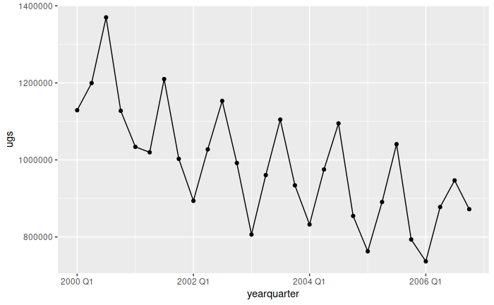

```r
data %>%
  filter(!is.na(ugs)) %>%
  ggplot(aes(x=yearquarter, y=ugs)) + geom_line() + geom_point()
```

## 3.2. Autocorrelation Function of UGS

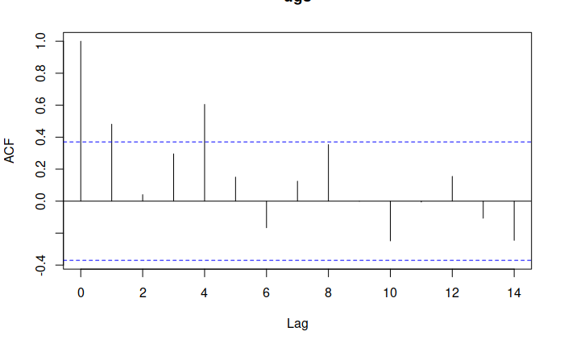

```r
data %>%
  filter(!is.na(ugs)) %>%
  select(ugs) %>%
  acf()
```

## 3.3. Pairs Plot

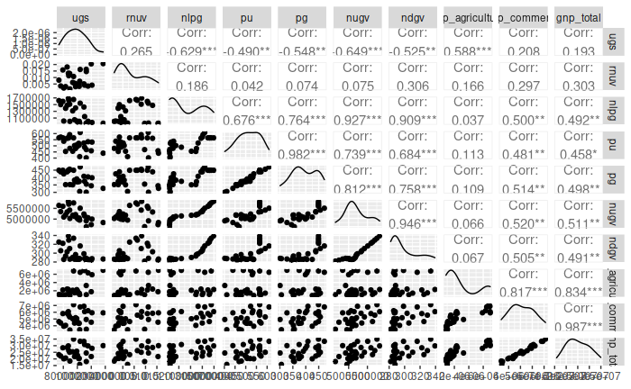

```r
data %>%
  select(-c(quarter, yearquarter)) %>%
  filter(!is.na(ugs)) %>%
  ggpairs()
```

Looking at the correlations, it seems like nugv, nlpg and gnp_agriculture are the most correlated variables with ugs, and pg, ndgv and pu are also highly correlated. These correlation levels will be useful when we need to introduce independent variables to the model.

# 4. Forecasting with Regression

## 4.1. Defining Trend, Seasonality and Lagged Variables and Trying Regression Models Each Time

### 4.1.1. Modeling only with Trend

```r
data <- data %>%
  mutate(
    trend = 1:nrow(data)
  )

data %>% slice_head(n=5)
```

| quarter | ugs | rnuv | nlpg | pu | pg | nugv | ndgv | gnp_agriculture | gnp_commerce | gnp_total | yearquarter | trend |
| --- | --- | --- | --- | --- | --- | --- | --- | --- | --- | --- | --- | --- |
| 2000_Q1 | 1128971 | 0.0146 | 940000 | 469.03 | 355.69 | 4647500 | 281.9853 | 1040173 | 3483132 | 18022686 | 2000 Q1 | 1 |
| 2000_Q2 | 1199569 | 0.0205 | 941000 | 459.42 | 344.58 | 4742876 | 284.0813 | 1760460 | 4525451 | 21797130 | 2000 Q2 | 2 |
| 2000_Q3 | 1370167 | 0.0207 | 943500 | 439.98 | 327.21 | 4840931 | 286.7169 | 6974808 | 5915204 | 30050207 | 2000 Q3 | 3 |
| 2000_Q4 | 1127548 | 0.0163 | 948000 | 402.08 | 300.67 | 4919685 | 288.3137 | 3267125 | 4929778 | 24480153 | 2000 Q4 | 4 |
| 2001_Q1 | 1033918 | 0.0071 | 950000 | 411.58 | 305.75 | 4954754 | 287.6237 | 1004528 | 3418387 | 15832648 | 2001 Q1 | 5 |

```r
lm1 <- lm(ugs~trend, data=data)
summary(lm1)
```

```
Call:
lm(formula = ugs ~ trend, data = data)

Residuals:
    Min      1Q  Median      3Q     Max
-199945  -73550  -21904   71224  237369

Coefficients:
            Estimate Std. Error t value Pr(>|t|)
(Intercept)  1170777      43292  27.043  < 2e-16 ***
trend         -12660       2608  -4.854 4.95e-05 ***
---
Signif. codes:  0 ‘***’ 0.001 ‘**’ 0.01 ‘*’ 0.05 ‘.’ 0.1 ‘ ’ 1

Residual standard error: 111500 on 26 degrees of freedom
  (4 observations deleted due to missingness)
Multiple R-squared:  0.4754,    Adjusted R-squared:  0.4552
F-statistic: 23.56 on 1 and 26 DF,  p-value: 4.945e-05
```

According to the output above, trend variable is highly significant, but R-squared value is small, so the model can and should be improved.

```
    Breusch-Godfrey test for serial correlation of order up to 6

data:  Residuals
LM test = 19.942, df = 6, p-value = 0.002836
```

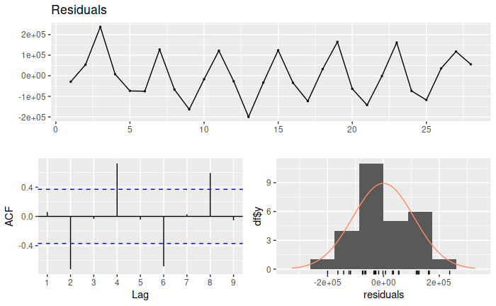

```r
checkresiduals(lm1)
```

Looking at the residuals line graph, it is hard to say that they are independent. A “zigzag” pattern can be seen. So, it can be said that there is still room for explaining the outcome variable more with the model. Also, the autocorrelation function indicates that at lags 4 and 8, there are high positive autocorrelation, and at lags 2 and 6 there are high negative autocorrelation. This is in line with the previous observation of 4 period seasonality. Also, the high autocorrelation at lag 2 itself hints that using a 2-step lagged variable may be beneficial.

### 4.1.2. Adding Seasonality to the Model

```r
data <- data %>%
  mutate(
    quarter_in_year = as.factor(rep(1:4, times=nrow(data)/4))
  )

data %>% slice_head(n=5)
```

| quarter | ugs | rnuv | nlpg | pu | pg | nugv | ndgv | gnp_agriculture | gnp_commerce | gnp_total | yearquarter | trend | quarter_in_year |
| --- | --- | --- | --- | --- | --- | --- | --- | --- | --- | --- | --- | --- | --- |
| 2000_Q1 | 1128971 | 0.0146 | 940000 | 469.03 | 355.69 | 4647500 | 281.9853 | 1040173 | 3483132 | 18022686 | 2000 Q1 | 1 | 1 |
| 2000_Q2 | 1199569 | 0.0205 | 941000 | 459.42 | 344.58 | 4742876 | 284.0813 | 1760460 | 4525451 | 21797130 | 2000 Q2 | 2 | 2 |
| 2000_Q3 | 1370167 | 0.0207 | 943500 | 439.98 | 327.21 | 4840931 | 286.7169 | 6974808 | 5915204 | 30050207 | 2000 Q3 | 3 | 3 |
| 2000_Q4 | 1127548 | 0.0163 | 948000 | 402.08 | 300.67 | 4919685 | 288.3137 | 3267125 | 4929778 | 24480153 | 2000 Q4 | 4 | 4 |
| 2001_Q1 | 1033918 | 0.0071 | 950000 | 411.58 | 305.75 | 4954754 | 287.6237 | 1004528 | 3418387 | 15832648 | 2001 Q1 | 5 | 1 |

```r
lm2 <- lm(ugs ~ -1 + trend + quarter_in_year, data=data)
summary(lm2)
```

```
Call:
lm(formula = ugs ~ -1 + trend + quarter_in_year, data = data)

Residuals:
   Min     1Q Median     3Q    Max
-81167 -31283  -3458  28640  94502

Coefficients:
                 Estimate Std. Error t value Pr(>|t|)
trend              -13497       1147  -11.76 3.28e-11 ***
quarter_in_year1  1060372      23653   44.83  < 2e-16 ***
quarter_in_year2  1181904      24393   48.45  < 2e-16 ***
quarter_in_year3  1333991      25164   53.01  < 2e-16 ***
quarter_in_year4  1155421      25962   44.51  < 2e-16 ***
---
Signif. codes:  0 ‘***’ 0.001 ‘**’ 0.01 ‘*’ 0.05 ‘.’ 0.1 ‘ ’ 1

Residual standard error: 48570 on 23 degrees of freedom
  (4 observations deleted due to missingness)
Multiple R-squared:  0.9981,    Adjusted R-squared:  0.9976
F-statistic:  2361 on 5 and 23 DF,  p-value: < 2.2e-16
```

I decided not to include intercept, so that the effects of all quarters can be visible. And effects of all quarters look significant. R-squared and adjusted R-squared values also have significantly improved comparing to previous model.

```
    Breusch-Godfrey test for serial correlation of order up to 8

data:  Residuals
LM test = 11.462, df = 8, p-value = 0.1769
```

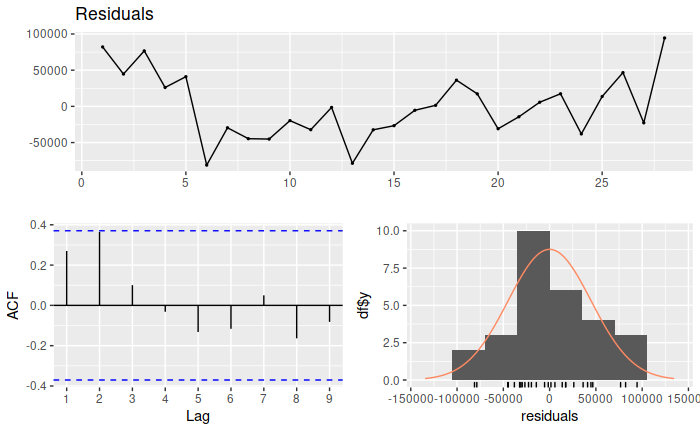

```r
checkresiduals(lm2)
```

In the autocorrelation graph above, it can be seen that the autocorrelation levels at many lags have been reduced a lot. The relatively high autocorrelation values may be indicating that adding one and/or two step lagged variables may improve the model performance.

### 4.1.3. Adding Lagged Variables to the Model

```r
data <- data %>%
  mutate(
    lagged_1 = lag(ugs),
    lagged_2 = lag(ugs, n=2)
  )

data
```

| quarter | ugs | rnuv | nlpg | pu | pg | nugv | ndgv | gnp_agriculture | gnp_commerce | gnp_total | yearquarter | trend | quarter_in_year | lagged_1 | lagged_2 |
| --- | --- | --- | --- | --- | --- | --- | --- | --- | --- | --- | --- | --- | --- | --- | --- |
| 2000_Q1 | 1128971 | 0.0146 | 940000 | 469.03 | 355.69 | 4647500 | 281.9853 | 1040173 | 3483132 | 18022686 | 2000 Q1 | 1 | 1 | NA | NA |
| 2000_Q2 | 1199569 | 0.0205 | 941000 | 459.42 | 344.58 | 4742876 | 284.0813 | 1760460 | 4525451 | 21797130 | 2000 Q2 | 2 | 2 | 1128971 | NA |
| 2000_Q3 | 1370167 | 0.0207 | 943500 | 439.98 | 327.21 | 4840931 | 286.7169 | 6974808 | 5915204 | 30050207 | 2000 Q3 | 3 | 3 | 1199569 | 1128971 |
| 2000_Q4 | 1127548 | 0.0163 | 948000 | 402.08 | 300.67 | 4919685 | 288.3137 | 3267125 | 4929778 | 24480153 | 2000 Q4 | 4 | 4 | 1370167 | 1199569 |
| 2001_Q1 | 1033918 | 0.0071 | 950000 | 411.58 | 305.75 | 4954754 | 287.6237 | 1004528 | 3418387 | 15832648 | 2001 Q1 | 5 | 1 | 1127548 | 1370167 |
| 2001_Q2 | 1019754 | 0.0051 | 955000 | 520.39 | 374.78 | 4980204 | 287.8814 | 1449357 | 4359831 | 20296918 | 2001 Q2 | 6 | 2 | 1033918 | 1127548 |
| 2001_Q3 | 1209916 | 0.0041 | 967500 | 530.37 | 398.71 | 5000446 | 287.5452 | 5890424 | 5925547 | 28017963 | 2001 Q3 | 7 | 3 | 1019754 | 1033918 |
| 2001_Q4 | 1002789 | 0.0048 | 990000 | 496.35 | 370.70 | 5024693 | 286.9786 | 1940854 | 4559190 | 22656812 | 2001 Q4 | 8 | 4 | 1209916 | 1019754 |
| 2002_Q1 | 893722 | 0.0012 | 1000000 | 479.52 | 352.72 | 5030810 | 286.3783 | 832953 | 3374849 | 18393446 | 2002 Q1 | 9 | 1 | 1002789 | 1209916 |
| 2002_Q2 | 1027252 | 0.0032 | 1001000 | 506.36 | 373.44 | 5046960 | 286.0471 | 1419764 | 4363782 | 20382635 | 2002 Q2 | 10 | 2 | 893722 | 1002789 |

[output cut: 22 more lines]

```r
lm3 <- lm(ugs ~ -1+trend+quarter_in_year+lagged_2, data=data)
summary(lm3)
```

```
Call:
lm(formula = ugs ~ -1 + trend + quarter_in_year + lagged_2, data = data)

Residuals:
   Min     1Q Median     3Q    Max
-78490 -25706  10316  20897  55505

Coefficients:
                   Estimate Std. Error t value Pr(>|t|)
trend            -5.401e+03  2.940e+03  -1.837  0.08113 .
quarter_in_year1  3.617e+05  2.673e+05   1.354  0.19099
quarter_in_year2  5.840e+05  2.293e+05   2.547  0.01919 *
quarter_in_year3  7.835e+05  2.137e+05   3.667  0.00153 **
quarter_in_year4  5.445e+05  2.373e+05   2.294  0.03273 *
lagged_2          4.848e-01  1.937e-01   2.504  0.02107 *
---
Signif. codes:  0 ‘***’ 0.001 ‘**’ 0.01 ‘*’ 0.05 ‘.’ 0.1 ‘ ’ 1

Residual standard error: 39940 on 20 degrees of freedom
  (6 observations deleted due to missingness)
Multiple R-squared:  0.9987,    Adjusted R-squared:  0.9984
F-statistic:  2628 on 6 and 20 DF,  p-value: < 2.2e-16
```

```
    Breusch-Godfrey test for serial correlation of order up to 9

data:  Residuals
LM test = 15.455, df = 9, p-value = 0.07917
```

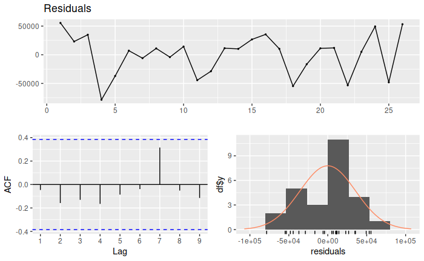

```r
checkresiduals(lm3)
```